# Rationale for MASSExtra

Bill Venables

2023-02-16

# Preamble

This extension package to the classical `MASS` package (Venables & Ripley, of ancient lineage), whose origins go back to nearly 30 years, comes about for a number of reasons.

Firstly, in my teaching I found I was using some of the old functions in the package with consistently different argument settings to the defaults. I was also interested in supplying various convenience extensions that simplified teaching and including various tweaks to improve the interface. Examples follow below.

Secondly, I wanted to provide a few functions that were mainly useful as programming examples. For example, the function `zs` and its allies `zu`, `zq` and `zr` are mainly alternatives to `base::scale`, but they can be used to show how to write functions that can be used in fitting models in such a way that they work as they should when the fitted model object is used for prediction with new data.

### Masking `select` from other packages

Finally, there is the perennial `select` problem. When `MASS` is used with other packages, such as `dplyr` the `select` function can easily be masked, causing confusion for users. `MASS::select` is rarely used, but `dplyr::select` is fundamental. There are standard ways of managing this kind of masking, but what we have done in `MASSExtra` is to export the more common functions used from `MASS` along with the extensions, in such a way that users will not need to have `MASS` attached to the search path at all, and hence masking is unlikely.

The remainder of this document will do a walk-through of some of the new functions provided by the package. We begin by setting the computational context:

```r
suppressPackageStartupMessages({
  library(visreg)
  library(knitr)
  library(dplyr)
  library(ggplot2)
  library(patchwork)
  library(MASSExtra)
})
options(knitr.kable.NA = "")
theme_set(theme_bw() + theme(plot.title = element_text(hjust = 0.5)))
```

# Amble

We now consider some of the extensions that the package offers to the originals. Most of the extensions will have a name that includes an underscore of two somewhere to distinguish it from the V&R original. Note that the original version is *also* exported so that scripts that use it may do so without change, via the new package.

## The `box_cox` extensions

This original version, `boxcox` has a fairly rigid display for the plotted output which has been changed to give a more easily appreciated result. The $y-$axis has been changed to give the likelihood-ratio statistic rather than the log-likelihood, and for the $x-$axis some attempt has been made to focus on the crucial region for the transformation parameter, $\lambda$,

The following example shows the old and new plot versions for a simple example.

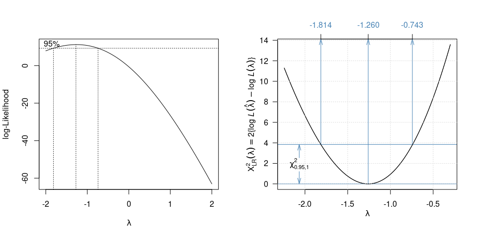

Box-cox, old and new displays

```r
par(mfrow = c(1, 2))
mod0 <- lm(MPG.city ~ Weight, Cars93)
boxcox(mod0)  ## MASS
box_cox(mod0) ## MASSExtra tweak
```

In addition, there are functions `bc` to evaluate the transformation for a given exponent, and a function `lambda` which finds the optimum exponent (not that a precise exponent will usually be needed).

It is interesting to see how in this instance the transformation can both straighten the relationship and provide a scale in which the variance is more homogeneous. See Figure 2.

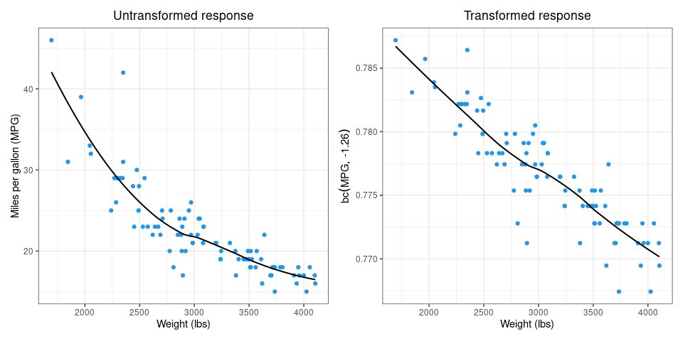

The Box-Cox transformation effect

```r
p0 <- ggplot(Cars93) + aes(x = Weight) + geom_point(colour = "#2297E6")  + xlab("Weight (lbs)") +
  geom_smooth(se = FALSE, method = "loess", formula = y ~ x, size=0.7, colour = "black")
p1 <- p0 + aes(y = MPG.city) + ylab("Miles per gallon (MPG)") + ggtitle("Untransformed response")
p2 <- p0 + aes(y = bc(MPG.city, lambda(mod0))) + ggtitle("Transformed response") +
  ylab(bquote(bc(MPG, .(round(lambda(mod0), 2)))))
p1 + p2
```

A more natural scale to use, consistent with the Box-Cox suggestion, would be the reciprocal. For example we could use $\mbox{GPM} = 100/\mbox{MPG}$ the “gallons per 100 miles” scale, which would have the added benefit of being more-or-less what the rest of the world uses to gauge fuel efficiency outside the USA. Readers should try this for themselves.

## Stepwise model building extensions

The primary `MASS` functions for refining linear models and their allies are `dropterm` and `stepAIC`. The package provides a few extensions to these, but mainly a change of defaults in the argument settings.

1. `drop_term` is a front-end to `MASS::dropterm` with a few tweaks. By default the result is arranged in sorted order, i.e. with `sorted = TRUE`, and also by default with `test = TRUE` (somewhat in defiance of much advice to the contrary given by experienced practitioners: *caveat emptor!*).

   The user may specify the test to use in the normal way, but the default test is decided by an ancillary generic function, `default_test`, which guesses the appropriate test from the object itself. This is an S3 generic and further methods can be supplied for new fitted model objects.

   There is also a function `add_term` which provides similar enhancements to those provided by `drop_term`. In this case, of course, the consequences of *adding* individual terms to the model are displayed, rather than of *dropping* them. It follows that using `add_term` you will always need to provide a scope specification, that is, some specification of what extra terms are possible additions.

   In addition `drop_term` and `add_term` return an object which retains information on the criterion used, `AIC`, `BIC`, `GIC` (see below) or some specific penalty value `k`. The object also has a class `"drop_term"` for which a `plot` method is provided. Both the `plot` and `print` methods display the criterion. See the example below for how this is done.
2. `step_AIC` is a front-end to `MASS::stepAIC` with the default argument `trace = FALSE` set. This may of course be over-ruled, but it seems the most frequent choice by users, anyway. In addition the actual criterion used, by dafault `k = 2`, i.e. AIC, is retained with the result and passed on to methods in much the same say as for `drop_term` above.

   Since the (default) criterion name is encoded in the function name, two further versions are supplied, namely `step_BIC` and `step_GIC` (again, see below), which use a different, and obvious, default criterion.

   In any of `step_AIC`, `step_BIC` or `step_GIC` a different value of `k` may be specified in which case that value of `k` is retained with the object and displayed as appropriate in further methods.

   Finally in any of these functions `k` may be specified either as a numeric penalty, such as `k = 4` for example, or by character string `k = "AIC"` or `k = "BIC"` with an obvious meaning in either case.
3. Criteria. The **Akaike Information Criterion**, AIC, corresponds to a penalty `k = 2` and the **Bayesian Information Criterion**, BIC, corresponds to `k = log(n)` where `n` is the sample size. In addition to these two the present functions offer an intermediate default penalty `k = (2 + log(n))/2` which is “not too strong and not too weak”, making it the **Goldilocks Information Criterion**, GIC. There is also a standalone function `GIC` to evaluate this `k` if need be.

   This suggestion appears to be original, but *no particular claim is made for it* other than with intermediate to largish data sets it has proved useful for exploratory purposes in our experience.

   Our strong advice is that these tools should *only* be used for exploratory purposes in any case, and should *never* be used in isolation. They have a well-deserved very negative reputation when misused, as they commonly are.

## Examples

We consider the well-known (and much maligned) Boston house price data. See `?Boston`. We begin by fitting a model that has more terms in it than the usual model, as it contains a few extra quadratic terms, including some key linear by linear interactions.

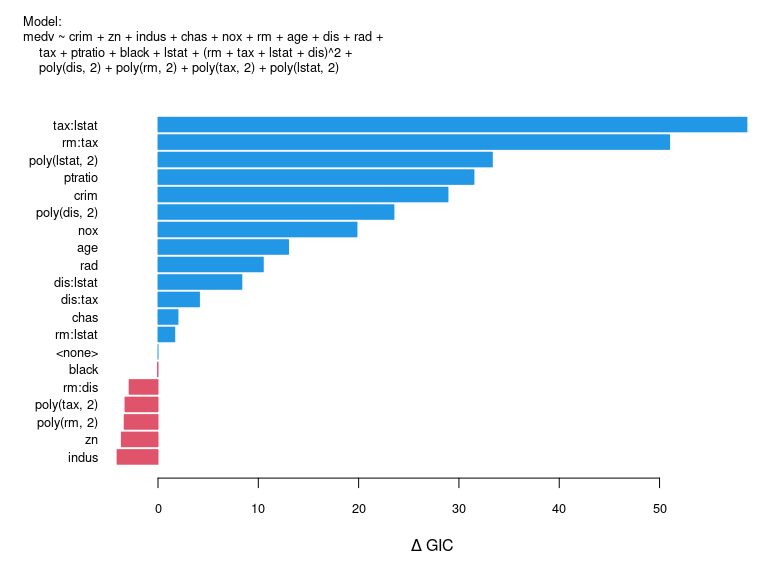

|  | Df | Sum of Sq | RSS | delta_GIC | F Value | Pr(F) |
| --- | --- | --- | --- | --- | --- | --- |
| tax:lstat | 1 | 728.695 | 6241.320 | 58.707 | 63.714 | 0.000 |
| rm:tax | 1 | 634.356 | 6146.981 | 51.000 | 55.465 | 0.000 |
| poly(lstat, 2) | 1 | 423.361 | 5935.985 | 33.327 | 37.017 | 0.000 |
| ptratio | 1 | 401.916 | 5914.540 | 31.495 | 35.142 | 0.000 |
| crim | 1 | 371.709 | 5884.334 | 28.905 | 32.501 | 0.000 |
| poly(dis, 2) | 1 | 309.410 | 5822.034 | 23.519 | 27.053 | 0.000 |
| nox | 1 | 267.160 | 5779.784 | 19.833 | 23.359 | 0.000 |
| age | 1 | 189.742 | 5702.366 | 13.010 | 16.590 | 0.000 |
| rad | 1 | 161.441 | 5674.065 | 10.492 | 14.116 | 0.000 |
| dis:lstat | 1 | 137.523 | 5650.148 | 8.355 | 12.024 | 0.001 |
| dis:tax | 1 | 90.529 | 5603.153 | 4.129 | 7.915 | 0.005 |
| chas | 1 | 66.861 | 5579.485 | 1.987 | 5.846 | 0.016 |
| rm:lstat | 1 | 63.305 | 5575.929 | 1.664 | 5.535 | 0.019 |
|  |  |  | 5512.624 | 0.000 |  |  |
| black | 1 | 44.479 | 5557.103 | -0.047 | 3.889 | 0.049 |
| rm:dis | 1 | 13.525 | 5526.149 | -2.873 | 1.183 | 0.277 |
| poly(tax, 2) | 1 | 9.012 | 5521.636 | -3.287 | 0.788 | 0.375 |
| poly(rm, 2) | 1 | 8.130 | 5520.755 | -3.368 | 0.711 | 0.400 |
| zn | 1 | 5.035 | 5517.659 | -3.651 | 0.440 | 0.507 |
| indus | 1 | 0.405 | 5513.029 | -4.076 | 0.035 | 0.851 |

```r
big_model <- lm(medv ~ . + (rm + tax + lstat + dis)^2 + poly(dis, 2) + poly(rm, 2) +
                   poly(tax, 2) + poly(lstat, 2), Boston)
big_model %>% drop_term(k = "GIC") %>% plot() %>% kable(booktabs=TRUE, digits=3)
```

Unlike `MASS::dropterm`, the table shows the terms beginning with the most important ones, that is those which, if dropped, would *increase* the criterion and ending with those of least looking importance, that is those whose removal would most *decrease* the criterion. And also note that here we are using the `GIC`, which is displayed in the output.

Note particularly that rather than give the *value* of the criterion by default the table and plot show *change* in the criterion which would result if the term is removed from the model at that point. This is a more meaningful quantity, and invariant with respect to the way in which the log-likelihood is defined.

The `plot` method gives a graphical view of the same key bits of information, in the same vertical order as given in the table. Terms whose removal would (at this point) improve the model are shown in *red* and those which would not, and hence should (again, at this point) be retained are shown in *blue*.

With all stepwise methods it is critically important to notice that the whole picture can change once any change is made to the current model. This terms which appear “promising” at this stage may not seem so once any variable is removed from the model or some other variable brought into it. This is a notoriously tricky area for the inexperienced.

Notice that the `plot` method returns the original object, which can then be passed on via a pipe to more operations. (`kable` does not, so this pipe sequence cannot be changed.)

We now consider a refinement of this model by stepwise means, but rather than use the large model as the starting point, we begin with a more modest one which has no quadratic terms.

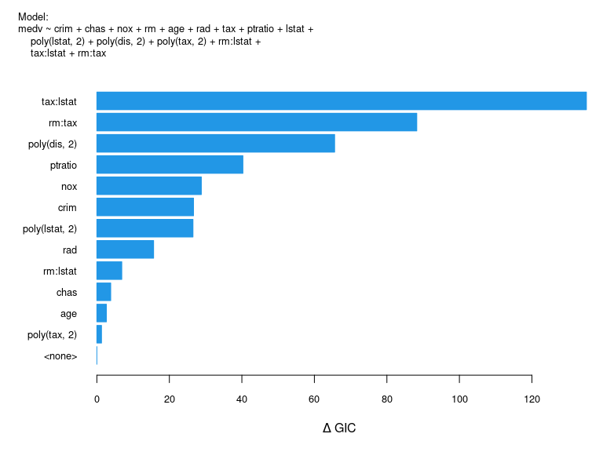

|  | Df | Sum of Sq | RSS | delta_GIC | F Value | Pr(F) |
| --- | --- | --- | --- | --- | --- | --- |
| tax:lstat | 1 | 1853.126 | 7707.733 | 135.034 | 154.780 | 0.000 |
| rm:tax | 1 | 1172.351 | 7026.958 | 88.244 | 97.919 | 0.000 |
| poly(dis, 2) | 2 | 919.601 | 6774.208 | 65.596 | 38.404 | 0.000 |
| ptratio | 1 | 537.017 | 6391.624 | 40.293 | 44.854 | 0.000 |
| nox | 1 | 393.819 | 6248.426 | 28.828 | 32.893 | 0.000 |
| crim | 1 | 367.257 | 6221.864 | 26.672 | 30.675 | 0.000 |
| poly(lstat, 2) | 1 | 365.333 | 6219.940 | 26.516 | 30.514 | 0.000 |
| rad | 1 | 233.292 | 6087.899 | 15.658 | 19.486 | 0.000 |
| rm:lstat | 1 | 128.612 | 5983.219 | 6.882 | 10.742 | 0.001 |
| chas | 1 | 92.617 | 5947.224 | 3.829 | 7.736 | 0.006 |
| age | 1 | 78.635 | 5933.242 | 2.638 | 6.568 | 0.011 |
| poly(tax, 2) | 1 | 62.892 | 5917.499 | 1.293 | 5.253 | 0.022 |
|  |  |  | 5854.607 | 0.000 |  |  |

```r
base_model <- lm(medv ~ ., Boston)
gic_model <- step_GIC(base_model, scope = list(lower = ~1, upper = formula(big_model)))
drop_term(gic_model) %>% plot() %>% kable(booktabs = TRUE, digits = 3)
```

The model is likely to be over-fitted. To follow up on this we could look at profiles of the fitted terms as an informal way of model ‘criticism’.

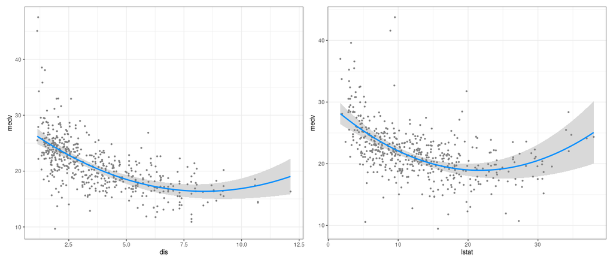

Two component visualisations for the Boston house price model

```r
capture.output(suppressWarnings({
   g1 <- visreg(gic_model, "dis", plot = FALSE)
   g2 <- visreg(gic_model, "lstat", plot = FALSE)
   plot(g1, gg = TRUE) + plot(g2, gg = TRUE)
})) -> void
```

The case for curvature appears to be fairly weak, in each case with departure from a straight line dependence depending on a relatively few observations with high values for the predictor. (Notice how hard you have to work to prevent `visreg` from generating unwanted output.)

As an example of `add_term`, consider going from what we have called the `base_model` to the `big_model`, or at least what might be the initial step:

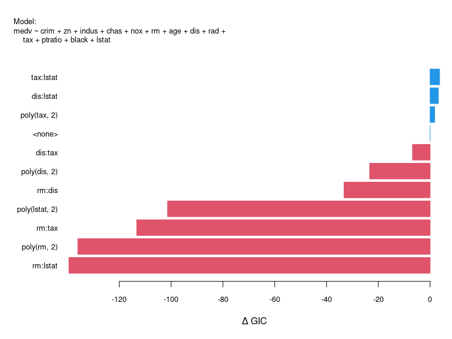

|  | Df | Sum of Sq | RSS | delta_GIC | F Value | Pr(F) |
| --- | --- | --- | --- | --- | --- | --- |
| tax:lstat | 1 | 10.105 | 11068.680 | 3.652 | 0.448 | 0.503 |
| dis:lstat | 1 | 20.414 | 11058.371 | 3.180 | 0.906 | 0.342 |
| poly(tax, 2) | 1 | 51.266 | 11027.518 | 1.766 | 2.283 | 0.131 |
|  |  |  | 11078.785 | 0.000 |  |  |
| dis:tax | 1 | 236.466 | 10842.318 | -6.804 | 10.708 | 0.001 |
| poly(dis, 2) | 1 | 585.089 | 10493.696 | -23.341 | 27.376 | 0.000 |
| rm:dis | 1 | 788.628 | 10290.157 | -33.252 | 37.630 | 0.000 |
| poly(lstat, 2) | 1 | 2084.780 | 8994.005 | -101.374 | 113.812 | 0.000 |
| rm:tax | 1 | 2293.787 | 8784.998 | -113.272 | 128.201 | 0.000 |
| poly(rm, 2) | 1 | 2679.861 | 8398.923 | -136.013 | 156.664 | 0.000 |
| rm:lstat | 1 | 2736.760 | 8342.024 | -139.452 | 161.082 | 0.000 |

```r
add_term(base_model, scope = formula(big_model), k = "gic") %>%
   plot() %>% kable(booktabs = TRUE, digits = 3)
```

So in this case, your best first step would be to *add* the term which most decreases the criterion, that is, the one nearest the bottom of the table (or display).

### Non-gaussian models

For a non-gaussian model consider the Quine data (`?quine`) example discussed in the *MASS* book. We begin by fitting a full negative binomial model and refine it using a stepwise algorithm.

```r
quine_full <- glm.nb(Days ~ Age*Eth*Sex*Lrn, data = quine)
drop_term(quine_full) %>% kable(booktabs = TRUE, digits = 4)
```

|  | Df | delta_AIC | LRT | Pr(Chi) |
| --- | --- | --- | --- | --- |
|  |  | 0.0000 |  |  |
| Age:Eth:Sex:Lrn | 2 | -2.5962 | 1.4038 | 0.4956 |

```r
quine_gic <- step_GIC(quine_full)
drop_term(quine_gic) %>% kable(booktabs = TRUE, digits = 4)
```

|  | Df | delta_GIC | LRT | Pr(Chi) |
| --- | --- | --- | --- | --- |
| Eth:Sex:Lrn | 1 | 8.9298 | 12.4216 | 4e-04 |
| Age:Sex | 3 | 8.1439 | 18.6193 | 3e-04 |
|  |  | 0.0000 |  |  |

So GIC refinement has led to the same model as in the *MASS* book, which in more understandable form would be written `Days ~ Sex/(Age + Eth*Lrn)`. Note also that the default test is in this case the likelihood ratio test.

For a different example, consider an alternative way to model the MPG data, rather than transforming to an inverse scale, using a generalized linear model with an inverse link and a gamma response.

```r
mpg0 <- glm(MPG.city ~ Weight + Cylinders + EngineSize + Origin,
            family = Gamma(link = "inverse"), data = Cars93)
drop_term(mpg0) %>% kable(booktabs = TRUE, digits = 3)
```

|  | Df | Deviance | delta_AIC | F value | Pr(F) |
| --- | --- | --- | --- | --- | --- |
| Weight | 1 | 1.032 | 34.400 | 38.499 | 0.000 |
| Cylinders | 5 | 0.867 | 7.919 | 3.790 | 0.004 |
|  |  | 0.708 | 0.000 |  |  |
| Origin | 1 | 0.721 | -0.566 | 1.516 | 0.222 |
| EngineSize | 1 | 0.712 | -1.560 | 0.465 | 0.497 |

```r
mpg_gic <- step_down(mpg0, k = "gic")      ## simple backward elimination, mainly used for GLMMs
drop_term(mpg_gic) %>% kable(booktabs = TRUE, digits = 3)
```

|  | Df | Deviance | delta_GIC | F value | Pr(F) |
| --- | --- | --- | --- | --- | --- |
| Weight | 1 | 1.490 | 79.688 | 89.042 | 0.000 |
| Cylinders | 5 | 0.901 | 2.097 | 3.956 | 0.003 |
|  |  | 0.732 | 0.000 |  |  |

We can see something of how well the final model is performing by looking at a slightly larger model fitted on the fly in `ggplot`:

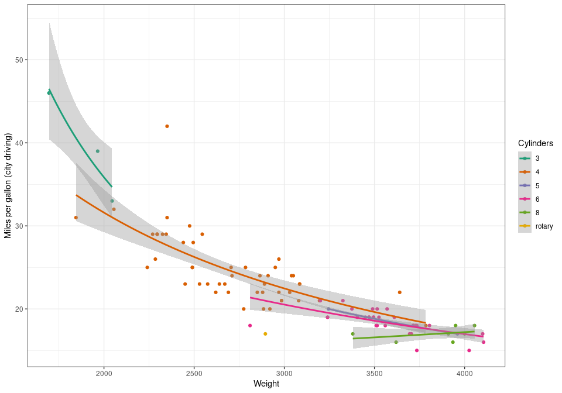

MPG model using a Gamma family with inverse link

```r
ggplot(Cars93) + aes(x = Weight, y = MPG.city, colour = Cylinders) + geom_point() +
   geom_smooth(method = "glm", method.args = list(family = Gamma), formula = y ~ x) +
   ylab("Miles per gallon (city driving)") + scale_colour_brewer(palette = "Dark2")
```

The function `step_down` is a simple implementation of backward elimination with the sole virtue that it works for (Generalised) Linear Mixed Models, or at least for the fixed effect component of them, whereas other stepwise methods do not (yet). As fitting GLMMs can be very slow, going through a full stepwise process could be very time consuming in any case.

## Scaling functions

When a function such as `base::scale`, `stats:poly` or `splines:ns` (also exported from `MASSExtra`) is used in modelling it is important that the fitted model object has enough information so that when it is used in prediction for new data, the same transformation can be put in place with the new predictor variable values. Setting up functions in such a way to enable this is a slightly tricky exercise. It involves writing a method function for the S3 generic function `stats::makepredictcall`. To illustrate this we have supplied four simple functions that employ the technique.

- `zs` (“z-score”) is essentially the same as `base::scale` with the default argument settings,
- `zu` allows re-scaling to a fixed range of [0, 1], often used in neural network models,
- `zq` allows a quantile scaling where the location is the lower quartile and the scale is the inter-quartile range. In other words, the scaling is to [0,1] *within the box* of a boxplot. *(Go figure.)*
- `zr` allows a “robust” scaling where the location is the median and the scale uses `stats::mad`

The only real interest in these very minor convenience functions lies in how they are programmed. See the code itself for more details.

## Kernel density estimation

Release 1.1.0 contains two functions for kernel density estimation: one- and two-dimensional.

- `kde_1d` offers a similar functionality to `stats::density`, though with two additional features that may be useful in some situations, namely
  - The kernel function may be specified as an R function, as well as as a character string to select from a preset list. Users wishing to write a special kernel function should do so in line with, for example `demoKde::kernelBiweight` or `demoKde::kernalGaussian`, using the same argument list with the same intrinsic meanings for the arguments themselves.
  - The kernel density estimate may be “folded” to emulate the effect of fitting a density with a known finite range for the underlying distribution. This amounts to fitting the kde initially with unrestricted range and “folding back” the parts beyond the known range, adding them on to the mirror image components inside the range. This strategy appears to give a credible result, though no particular claim is made for it on theoretical grounds. See the examples.
- `kde_2d` uses much the same computational ideas as in `MASS::kde2d` (due to Prof. Brian Ripley), but uses an approximation that allows the algorithm to scale much better for both large data sets and large resolution in the result. Indeed the approximation improves as the resolution increases, so the default size is now $512\times512$ rather than $25\times25$ as it is for `MASS::kde2d`. This function also allows the kernel function(s) to be either specified or user-defined, as for `kde_1d` above. Folding is not implemented, however.

Both functions produce objects with a class agreeing with the name of the calling function, and suitable `plot` and `print` methods are provided.

Two examples follow. The first shows (mainly) the surprising capacity for a log-transformation to amplify what is essentially a trivial effect into something that appears impressive!

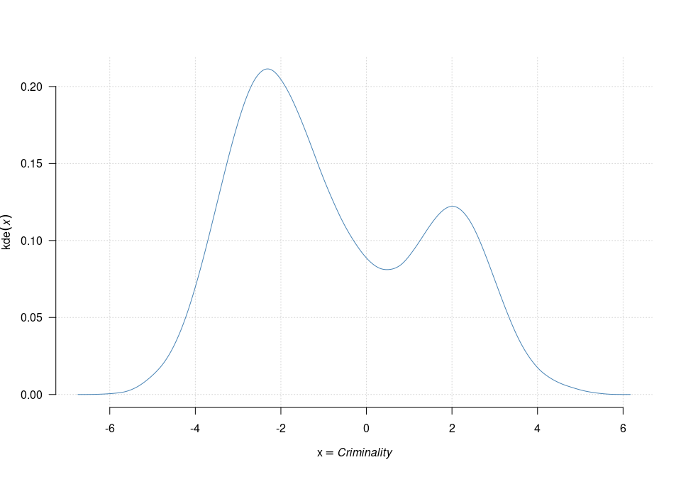

A one-dimensional KDE of a predictor variable from the Boston data set

```r
Criminality <- with(Boston, log(crim))
kcrim <- kde_1d(Criminality, n = 1024, kernel = demoKde::kernelBiweight)
kcrim
A Kernel Density Estimate of class  kde_1d

Response   : Criminality
Sample size: 506
Range      : -6.744 < x < 6.169
Bandwidth  : 0.5601
Resolution : 1024

Methods exist for generics: plot, print
plot(kcrim)
```

We now take this further into a two-dimensional example

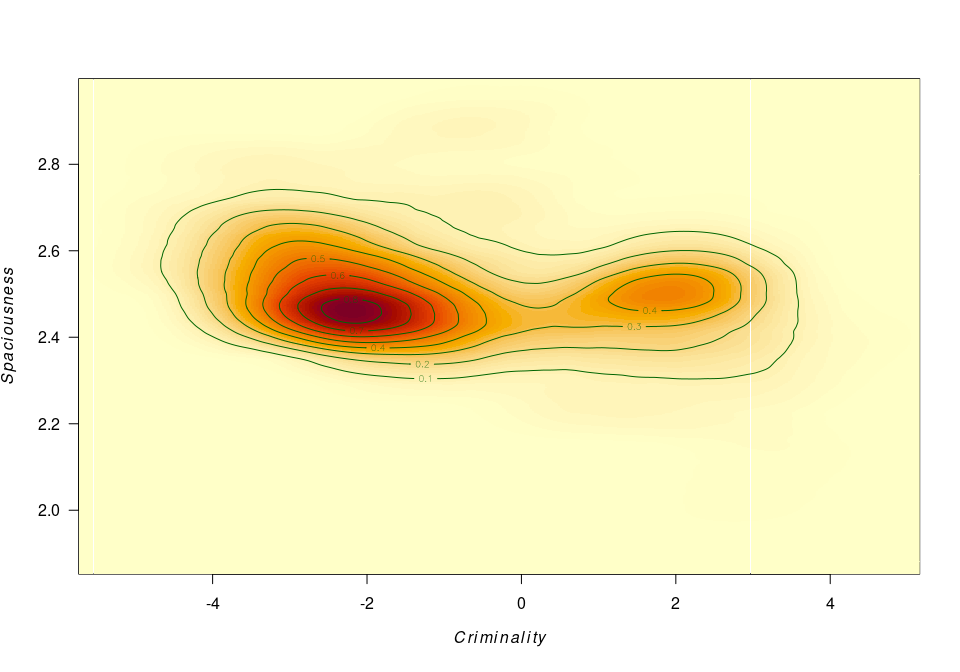

A two-dimensional KDE using two predictors from the Boston data set

```r
Spaciousness <- with(Boston, sqrt(rm))
kcrimrm <- kde_2d(Criminality, Spaciousness, n = 512, kernel = "opt")
kcrimrm
A Two-dimensional Kernel Density Estimate

Responses  : x, y
Sample size: 506
Ranges     : -5.724 < x < 5.148, 1.853 < y < 2.997
Bandwidths : 0.6597, 0.03361
Resolution : 512, 512

Methods exist for generics: hr_levels, plot, print
plot(kcrimrm, ## col = hcl.colors(25, rev = TRUE),
     xlab = expression(italic(Criminality)),
     ylab = expression(italic(Spaciousness)))
contour(kcrimrm, col = "dark green", add = TRUE)
```

An even more deceptive plot uses `persp`:

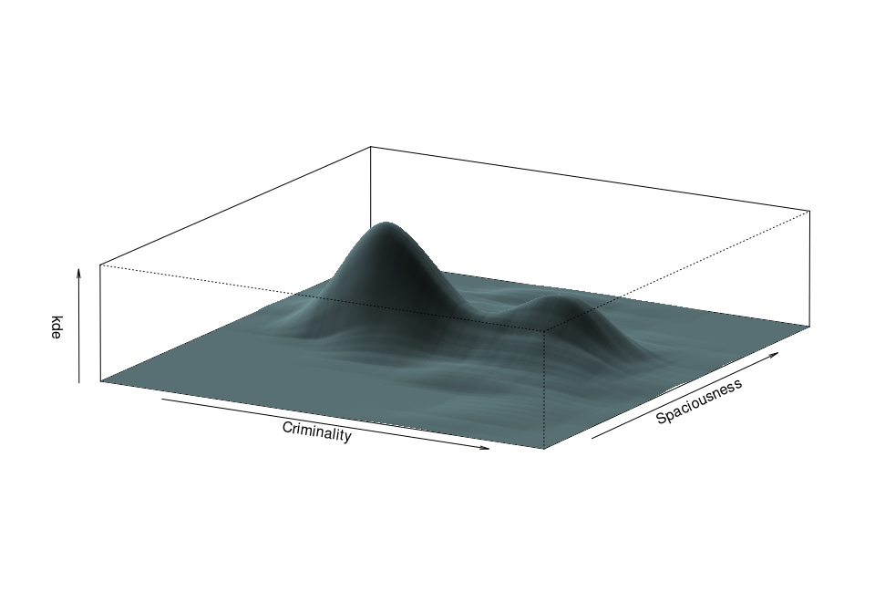

A two-dimensional KDE presented as a perspective plot

```r
with(kcrimrm, persp(x, 10*y, 3*z, border="transparent", col = "powder blue",
                    theta = 30, phi = 15, r = 100, scale = FALSE, shade = TRUE,
                    xlab = "Criminality", ylab = "Spaciousness", zlab = "kde"))
```

# Postamble

In this final section we mainly give a list of functions provided by the package, and their origins.

We begin by giving a list of functions in the `MASS` package which are *not* re-exported from the `MASSExtra` package. If you need any of these you will need either to attach the `MASS` package itself, or use the qualified form `MASS::<name>`.

```
 [1] Shepard           area              as.fractions      bandwidth.nrd
 [5] bcv               con2tr            contr.sdif        corresp
 [9] cov.mcd           cov.mve           cov.rob           cov.trob
[13] denumerate        dose.p            enlist            eqscplot
[17] fbeta             fitdistr          frequency.polygon gamma.dispersion
[21] gamma.shape       hist.FD           hist.scott        huber
[25] hubers            is.fractions      ldahist           lm.ridge
[29] lmsreg            loglm             loglm1            lqs.formula
[33] ltsreg            mca               nclass.freq       neg.bin
[37] negexp.SSival     parcoord          psi.bisquare      psi.hampel
[41] psi.huber         rational          renumerate        rms.curv
[45] select            truehist          write.matrix
```

The following objects *are* re-exported from the `MASSExtra` package, and hence may be used directly, if needed.

```
 [1] Null              addterm           boxcox            dropterm
 [5] fractions         ginv              glm.convert       glm.nb
 [9] glmmPQL           isoMDS            kde2d             lda
[13] lm.gls            logtrans          lqs               mvrnorm
[17] negative.binomial polr              qda               rlm
[21] rnegbin           sammon            stdres            stepAIC
[25] studres           theta.md          theta.ml          theta.mm
[29] ucv               width.SJ
```

The following functions are *new* to the `MASSExtra` package, some of which are obviously refinements of their `MASS` workhorse counterparts.

```
 [1] .normalise       GIC              add_term         as_complex
 [5] avoid            bc               bc_inv           box_cox
 [9] cm2in            default_test     drop_term        eigen2
[13] givens_orth      gs_orth          gs_orth_modified hr_levels
[17] in2cm            in2mm            in2usr           kde_1d
[21] kde_2d           lambda           mean_c           mm2in
[25] step_AIC         step_BIC         step_GIC         step_down
[29] usr2in           var_c            vcovx            which_tri
[33] zq               zr               zs               zu
```

Finally the following objects are re-exported from `splines`:

```
[1] bs ns
```

Only four of the `MASS` data sets are included in `MASSExtra`, namely `Cars93`, `Boston`, `quine` and `whiteside`. Other data sets from `MASS` itself will need to be accessed directly, e.g. `MASS::immer`.